# Claimant Count and Universal Credit in Trafford

# Claimant Count in Trafford

The [Claimant Count](https://www.nomisweb.co.uk/sources/cc) indicates the number of people claiming benefits principally for the reason of being unemployed. The Claimant Count in July 2026 was 29.9% higher than in January 2020. The rate of claimants to residents aged 16 to 64 was 3% in July 2026 representing an increment of 0.7% points from January 2020. The number of claimants decreased from April 2021. Since May 2025, the number of claims has not experience significant changes although is slighly rising in later months.

Change in the Claimant Count for Trafford compared to January 2020

| Date | count | rate | Change % |
| --- | --- | --- | --- |
| 2020-01-01 | 3415 | 2.3 | 0 |
| 2020-02-01 | 3600 | 2.5 | 5.4 |
| 2020-03-01 | 3615 | 2.5 | 5.9 |
| 2020-04-01 | 6590 | 4.5 | 93 |
| 2020-05-01 | 7745 | 5.3 | 126.8 |
| 2020-06-01 | 7520 | 5.2 | 120.2 |
| 2020-07-01 | 7750 | 5.3 | 126.9 |
| 2020-08-01 | 7855 | 5.4 | 130 |
| 2020-09-01 | 7815 | 5.4 | 128.8 |
| 2020-10-01 | 7600 | 5.2 | 122.5 |

[output cut: 69 more lines]

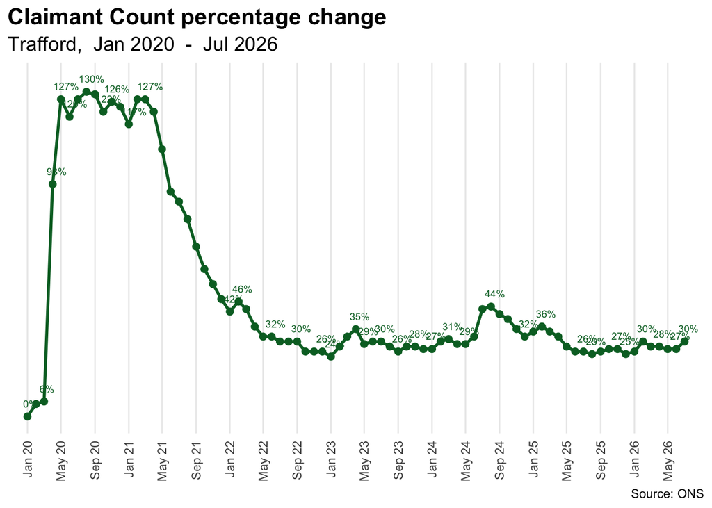

The Trafford MSOA with the largest share of claims in July 2026 was Old Trafford with 13.5% of all claimants within Trafford, 80% more claims than in Gorse Hill, the MSOA with the second largest number of claims. 60% of the MSOA has more claims in July 2026 compared to July 2025, and 1 MSOA had no additional claims. Partington have the largest increase in number of claims with 50 more, followed by Firswood with 40 additional claims. Old Trafford had the most reduction in number of claims with 25 less followed by West Timperley (15) and Bowdon (15).

Change in the Claimant Count for Trafford's MSOAs

| MSOA | Jul 2025 | Jul 2026 | Additional claims | Share Jul 26 | % Change | Jul 2025 | Jul 2026 | Change |
| --- | --- | --- | --- | --- | --- | --- | --- | --- |
| Old Trafford | 625 | 600 | -25 | 13.5 | -4 | 7.9 | 7.6 | -0.3 |
| Trafford Park West & Kingsway Park | 105 | 95 | -10 | 2.1 | -10 | 2.3 | 2 | -0.3 |
| Gorse Hill | 345 | 335 | -10 | 7.5 | -3 | 6 | 5.9 | -0.1 |
| Firswood | 290 | 330 | 40 | 7.4 | 14 | 5.1 | 5.8 | 0.7 |
| Davyhulme | 70 | 75 | 5 | 1.7 | 7 | 1.4 | 1.5 | 0.1 |
| Trafford Park East & Sevenways | 235 | 225 | -10 | 5.1 | -4 | 4.4 | 4.2 | -0.2 |
| Flixton & Moorside | 120 | 130 | 10 | 2.9 | 8 | 2.4 | 2.6 | 0.2 |
| Lostock & Stretford Meadows | 200 | 225 | 25 | 5.1 | 12 | 4.6 | 5.1 | 0.5 |
| Urmston East | 140 | 155 | 15 | 3.5 | 11 | 3 | 3.4 | 0.4 |
| Urmston West | 75 | 85 | 10 | 1.9 | 13 | 1.9 | 2.1 | 0.2 |

[output cut: 18 more lines]

The MSOAs with higher claimant rate in July 2026 were Old Trafford with 7.6%, Partington with 6.2% and Gorse Hill with 5.9%. The MSOAs where the claimant rate had increased more from July 2025 to July 2026 was Partington with 1% points increase. The MSOAs where the claimant rate have decreased more from July 2025 to July 2026 were Old Trafford, Trafford Park West & Kingsway Park, West Timperley and Bowdon with -0.3% points decrease each.

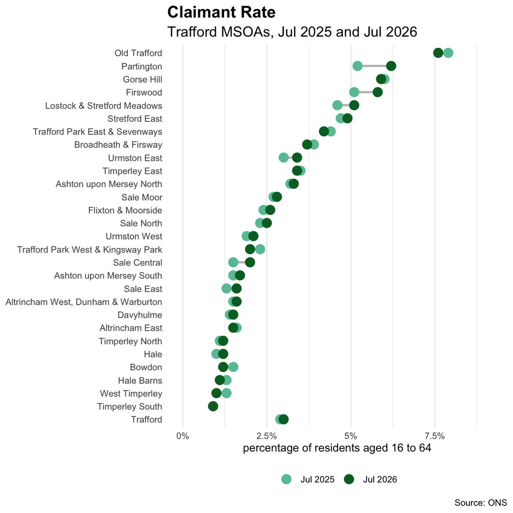

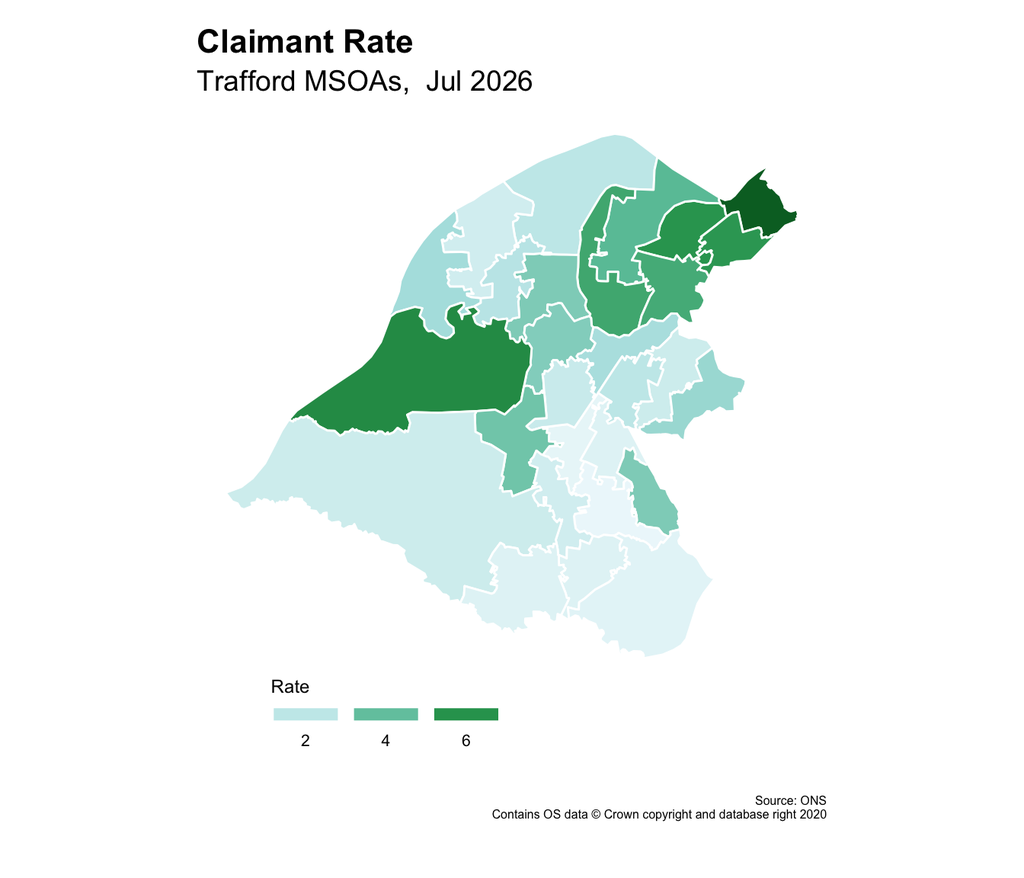

In Trafford, from July 2025 to July 2026, 3 out of 11 of the age bands has decreased the number of claimants. The age band 18-24 had the most increase with 55 more claimants. When considering the reduction of claims the age bands 25-29, 50-54 years had the largest reduction with -10, -10 less claims. Considering the broad age bands, all bands had increases.

Change in the Claimant Count by age bands in Trafford

| Age | Jul 2025 | Jul 2026 | Additional claims | % Change |
| --- | --- | --- | --- | --- |
| 16-17 | 0 | 5 | 5 | NA |
| 18-24 | 775 | 830 | 55 | 7 |
| 25-29 | 530 | 520 | -10 | -2 |
| 30-34 | 495 | 525 | 30 | 6 |
| 35-39 | 525 | 540 | 15 | 3 |
| 40-44 | 495 | 510 | 15 | 3 |
| 45-49 | 465 | 475 | 10 | 2 |
| 50-54 | 365 | 355 | -10 | -3 |
| 55-59 | 300 | 340 | 40 | 13 |
| 60-64 | 265 | 265 | 0 | 0 |

[output cut: 1 more lines]

Change in the Claimant Count by broad age bands in Trafford

| Age | Jul 2025 | Jul 2026 | Additional claims | % Change |
| --- | --- | --- | --- | --- |
| 16-24 | 775 | 835 | 60 | 8 |
| 25-49 | 2510 | 2570 | 60 | 2 |
| 50+ | 1000 | 1030 | 30 | 3 |
| 16+ | 4290 | 4435 | 145 | 3 |

At the start of 2020 the age band 25-34 already had the highest number of claims, however after the effects of the Covid-19 pandemic which started in March 2020 this figure increased more sharply compared to the other age bands. The claimant rate as a proportion of Trafford’s population within each age band showed then a higher increase in the age bands of 16-24 and 25-34 compared to the others. From January 2023 the count and rate of all age bands started to increase but the figures are fluctuating from April 2023.

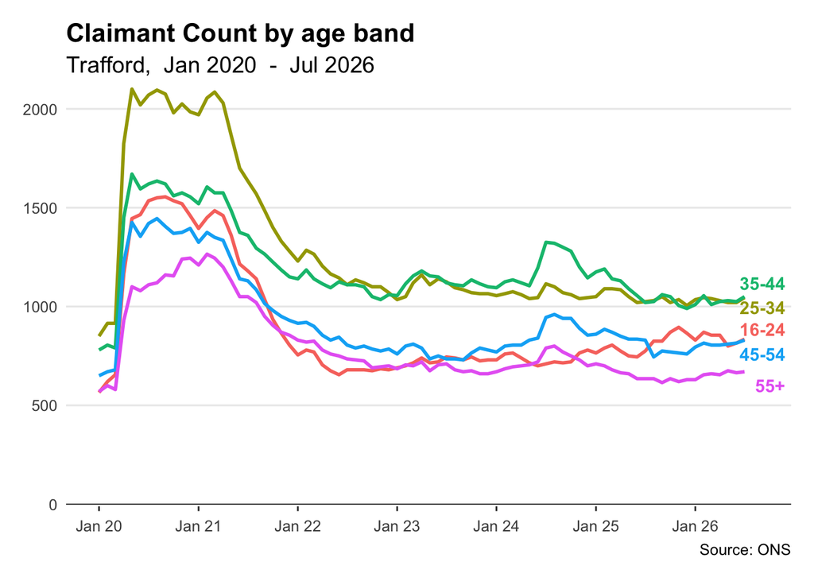

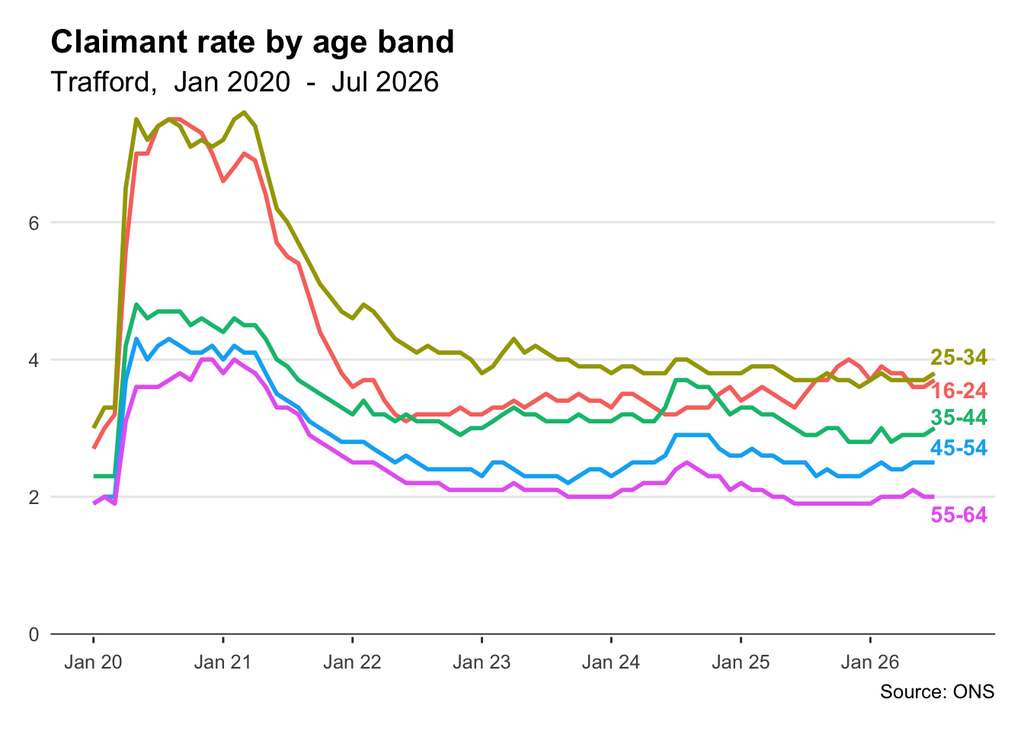

More than half of Trafford’s claimants are residents of 1 quarter of the MSOAs. Around half of the claimants are between 25 and 44 years.

Claimant Count for Trafford's MSOAs by age band

| MSOA | 16-17 | 18-24 | 25-34 | 35-44 | 45-54 | 55-64 | 65+ |
| --- | --- | --- | --- | --- | --- | --- | --- |
| Altrincham East | 0 | 15 | 15 | 25 | 20 | 20 | 0 |
| Altrincham West, Dunham & Warburton | 0 | 20 | 20 | 20 | 25 | 10 | 0 |
| Ashton upon Mersey North | 0 | 20 | 30 | 25 | 20 | 25 | 0 |
| Ashton upon Mersey South | 0 | 15 | 20 | 15 | 15 | 10 | 0 |
| Bowdon | 0 | 10 | 5 | 20 | 15 | 5 | 0 |
| Broadheath & Firsway | 0 | 40 | 55 | 65 | 45 | 25 | 5 |
| Davyhulme | 0 | 15 | 15 | 15 | 20 | 15 | 0 |
| Firswood | 0 | 60 | 85 | 65 | 65 | 50 | 5 |
| Flixton & Moorside | 0 | 40 | 25 | 30 | 20 | 10 | 5 |
| Gorse Hill | 0 | 70 | 80 | 105 | 45 | 30 | 5 |

[output cut: 18 more lines]

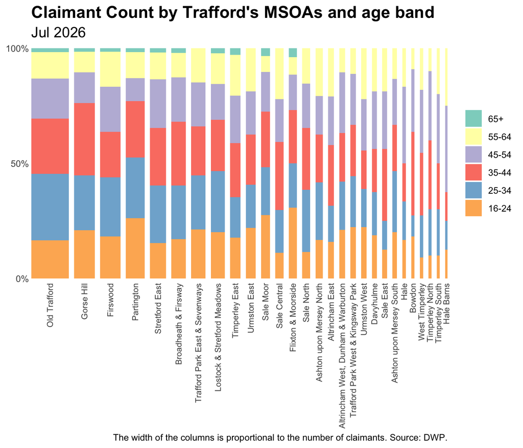

## Universal Credit claims in Trafford

The [Universal Credit](https://stat-xplore.dwp.gov.uk/webapi/metadata/UC_Monthly/UC_Monthly.html) claims in Trafford have increased 151.8% from January 2020 to May 2026. The rate of claims as a proportion of people age 16 to 64 increased form 6.1% to 15.4% from January 2020 to May 2026. Claimants are migrating from legacy benefits to Universal Credit which replace six means-tested benefits for working-age people: Working Tax Credit, Child Tax Credit, Housing Benefit, Income Support, income-based Jobseeker’s Allowance, and income-related Employment and Support Allowance (ESA).

Change in the Universal Credit claims for Trafford

| Date | value | rate | change |
| --- | --- | --- | --- |
| 2020-01-01 | 8919 | 6.1 | 0 |
| 2020-02-01 | 9271 | 6.4 | 3.9 |
| 2020-03-01 | 9444 | 6.5 | 5.9 |
| 2020-04-01 | 13410 | 9.1 | 50.4 |
| 2020-05-01 | 15979 | 10.8 | 79.2 |
| 2020-06-01 | 16381 | 11.3 | 83.7 |
| 2020-07-01 | 16638 | 11.4 | 86.5 |
| 2020-08-01 | 16716 | 11.4 | 87.4 |
| 2020-09-01 | 16973 | 11.5 | 90.3 |
| 2020-10-01 | 17046 | 11.5 | 91.1 |

[output cut: 67 more lines]

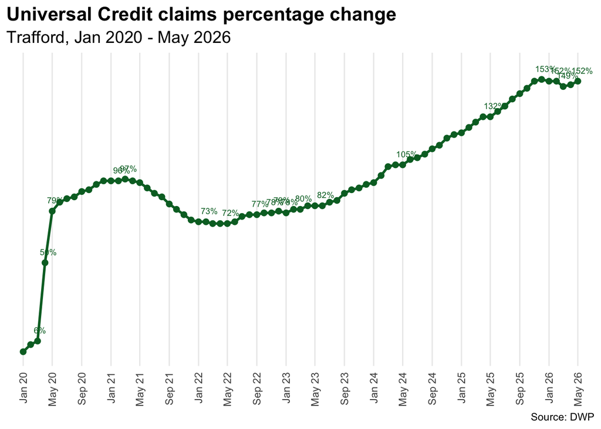

The Trafford MSOA with the largest share of claims in May 2026 was Old Trafford with 12.3% of all Universal Credit claims in Trafford. All but one MSOAs have more claims in May 2026 compared to May 2025. The MSOAs with more additional claims when comparing May 2025 to May 2026 were Old Trafford (188), Partington (158) and Lostock & Stretford Meadows (155). The MSOAs with more increase in percentage change from May 2025 to May 2026 were Urmston East with 22% change and Urmston West with 18% change.

Change in the Universal Credit claims for Trafford's MSOAs

| MSOA | May 2025 | May 2026 | Additional claims | % Change | Share May 26 | May 2025 | May 2026 | Change |
| --- | --- | --- | --- | --- | --- | --- | --- | --- |
| Old Trafford | 2566 | 2754 | 188 | 7 | 12.3 | 32.4 | 34.8 | 2.4 |
| Trafford Park West & Kingsway Park | 538 | 574 | 36 | 7 | 2.6 | 11.6 | 12.4 | 0.8 |
| Gorse Hill | 1429 | 1493 | 64 | 4 | 6.6 | 25 | 26.1 | 1.1 |
| Firswood | 1199 | 1337 | 138 | 12 | 6 | 20.9 | 23.3 | 2.4 |
| Davyhulme | 337 | 383 | 46 | 14 | 1.7 | 6.9 | 7.9 | 1 |
| Trafford Park East & Sevenways | 922 | 972 | 50 | 5 | 4.3 | 17.2 | 18.1 | 0.9 |
| Flixton & Moorside | 711 | 769 | 58 | 8 | 3.4 | 14.4 | 15.5 | 1.1 |
| Lostock & Stretford Meadows | 929 | 1084 | 155 | 17 | 4.8 | 21.2 | 24.8 | 3.6 |
| Urmston East | 601 | 731 | 130 | 22 | 3.3 | 13.1 | 15.9 | 2.8 |
| Urmston West | 333 | 394 | 61 | 18 | 1.8 | 8.3 | 9.8 | 1.5 |

[output cut: 18 more lines]

The MSOAs with higher rates of Universal Credit claims in May 2026 were Partington with 40.8% and Old Trafford with 34.8%. The MSOAs where the rate of Universal Credit claims has increased more from May 2025 to May 2026 were Lostock & Stretford Meadows with 3.6% points increase and Partington with 3.2% points increase.

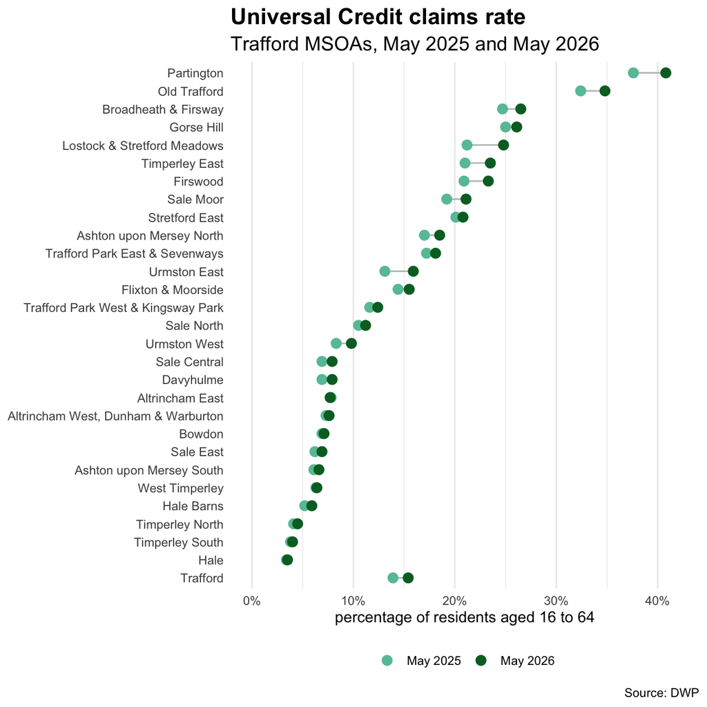

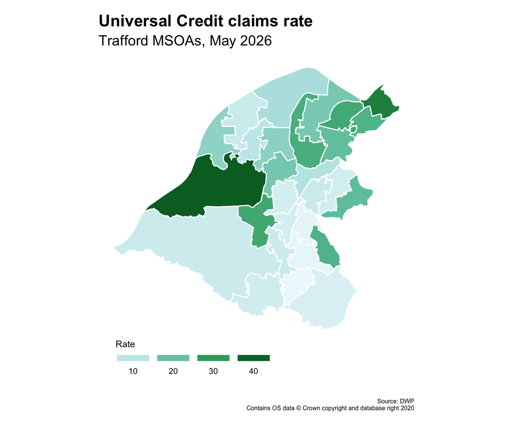

In Trafford from May 2025 to May 2026 the 65-70 age band has the largest increment in percentage change of Universal Credit claims with 42%. When considering the number of additional claims from May 2025 to May 2026 the 5-year age band 60-64 years had the highest with 518 more claims. All age bands had an increment of claims compared to May 2025.

Change in the Universal Credit claims by age band for Trafford

| Age | May 2025 | May 2026 | Additional claims | % Change |
| --- | --- | --- | --- | --- |
| 16-19 | 389 | 405 | 16 | 4 |
| 20-24 | 1512 | 1526 | 14 | 1 |
| 25-29 | 1888 | 2044 | 156 | 8 |
| 30-34 | 2408 | 2420 | 12 | 0 |
| 35-39 | 2988 | 3007 | 19 | 1 |
| 40-44 | 3013 | 3135 | 122 | 4 |
| 45-49 | 2503 | 2676 | 173 | 7 |
| 50-54 | 2118 | 2239 | 121 | 6 |
| 55-59 | 1839 | 2283 | 444 | 24 |
| 60-64 | 1608 | 2126 | 518 | 32 |

[output cut: 2 more lines]

Following the start of the Covid-19 pandemic in March 2020 the number of claims for all ages rose dramatically from pre-pandemic levels at a similar proportion for all age bands with the age band 16-24 rising faster in May 2020. At the start of 2020 the age band 25-34 had the highest number of claims and also the highest rate maintaining that position after the rise from March 2020 until May 2022 when the 35-44 became the age band with the highest number of claims. The age band 16-24 has the lowest number of claims among the other age bands from July 2021. All the age bands are increasing their number of claims particularly from January 2023, however ages 16 to 34 had remained more stable. From May 2025 the count and rate of claims from age 55 to 65 years has been steadily increasing but plateauing.

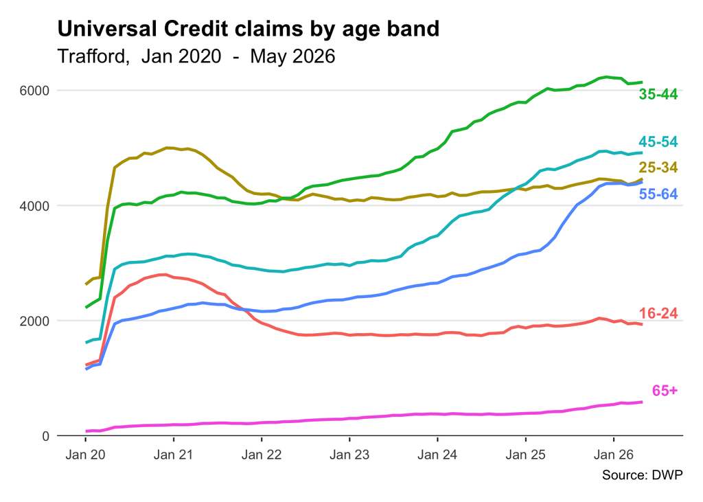

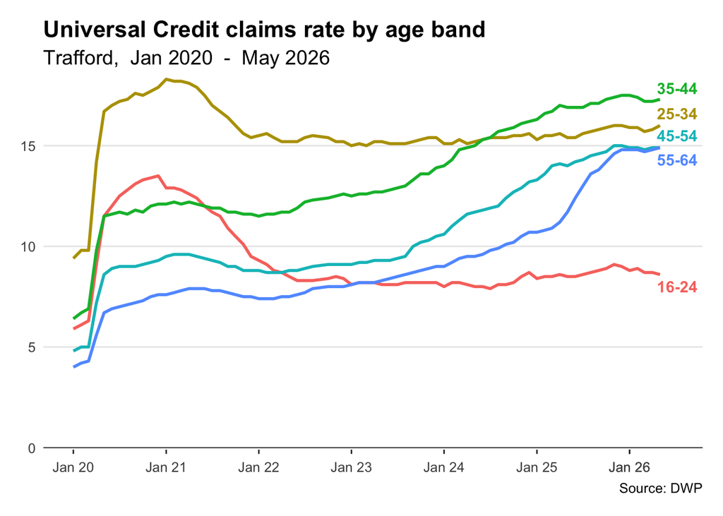

The [Conditionality](https://stat-xplore.dwp.gov.uk/webapi/metadata/UC_Monthly/Conditionality%20Regime.html) regimen for entitlement to Universal Credit is associated to work-related things that claimants will have to do to maintain eligibility. In Trafford the largest proportion of Universal Credit claims are in the “No work requirements” category however there is also a large proportion of claims under “Searching for work”. In Old Trafford, 50% of Universal Credit claimants were under “No work requirements” whilst 21% where “Searching for work”. In Partington, 60.5% of claims were under “No work requirements” whilst 13.6% under “Searching for work”, and 12.5% of claims were under “Working - no requirements”.

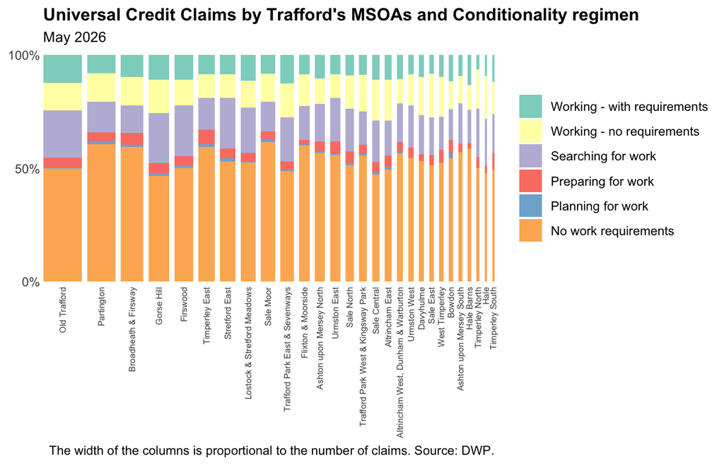

Claimants moving across from legacy benefits to Universal credit and new applications are increasing the number of claimants with no work requirements. Claimants with a disability or health condition which prevents them from working or if they provide care for at least 35 hours a week are not be asked to work. In May 2026, 54% (12,134) of claims in Trafford were under “No work requirements”, 17.6% (3,959) were under “Searching for work”, 13% (2,926) were under “Working - no requirements”, 10% (2,247) were under “Working - with requirements”, 4.4% (980) were under “Preparing for work”, and 0.9% (205) where under “Planning for work”.

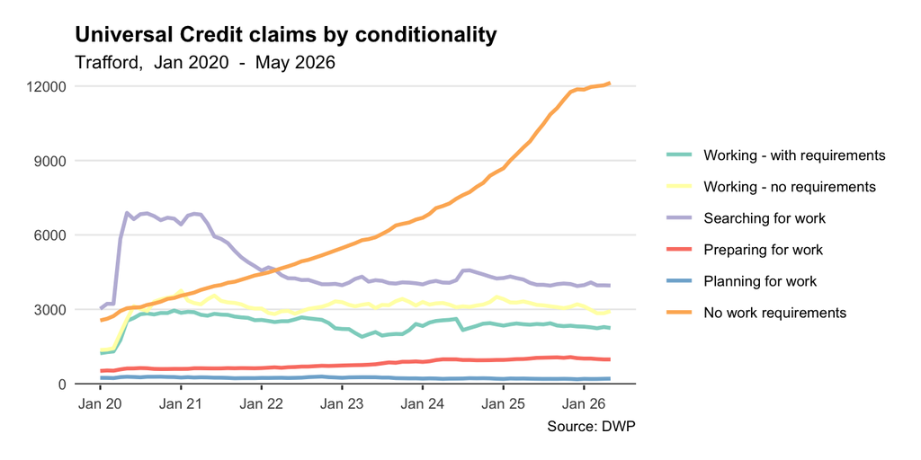

Households on Universal Credit can access additional entitlements for children, health and disabilities, housing, and carers, at the top of the standard allowance. Each household can receive more then one entitlement. As a consequence of the Covid-19 pandemic the number of entitlements showed a sudden increase whilst at the same time the proportion of household receiving entitlements decreased indicating a larger number of claims not receiving additional entitlements.

As claimants are migrating from legacy benefits to Universal Credit and new claims are reported, the number of household receiving an entitlement have been increasing. In the past year, there has been an increase in number of household receiving Limited Capability for Work Entitlement and the Housing Entitlement, and an increase in percentage of households receiving Limited Capacity for Work entitlement.

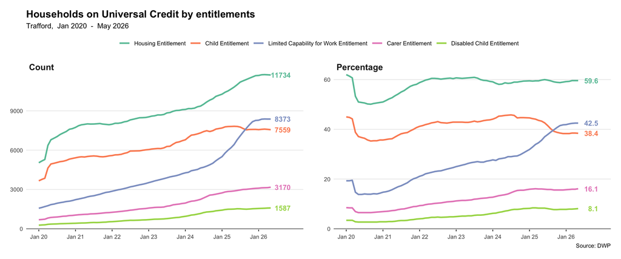